# Conceptual Questions Analysis

Jiarong Feng

2026-06-11

# Overview

This notebook analyzes the conceptual-question portion of the assessment. This section includes two forced-choice items and four open-ended text responses:

- **Choose-strongest-r items**: participants choose which scatterplot has the stronger correlation.
- **Switch X/Y questions**: participants explain what happens to correlation and slope when X and Y are swapped.
- **Same/different questions**: participants describe how slope and correlation are similar and different.

I treat these as a separate conceptual-question outcome family rather than combining them with value estimation or add-points performance. Value estimation and add-points are also assessment tasks, but they capture different kinds of understanding. Within this report, I treat the four open-ended responses as the primary conceptual outcome because they directly ask participants to articulate conceptual similarities and differences between slope and correlation. The two choose-strongest-r items are reported separately as a short recognition check.

# 1. Load data

| item | value |
| --- | --- |
| data_derived_dir | ../data/derived |
| participant_file | participant_condition_index.csv |
| choose_item_file | scored_choose_r_item_level.csv |
| choose_participant_file | scored_choose_r_participant_level.csv |
| raw_text_file | assessment_connection_making_long.csv |
| coded_text_file | conceptual_text_coding_sheet_coded.csv |
| prior_knowledge_file | prior_knowledge_coding_sheet_coded.csv |

## 1.1 Prior knowledge covariate

Prior knowledge is included as a covariate in the models below. I sum the pre-study correlation-definition score and slope-definition score into one composite prior-knowledge score. This keeps the covariate simple and interpretable. The composite ranges from 0 to 2.

| group | n_participants | mean_prior_correlation | mean_prior_slope | mean_prior_total | sd_prior_total |
| --- | --- | --- | --- | --- | --- |
| CC | 20 | 0.525 | 0.525 | 1.05 | 0.484 |
| CP | 20 | 0.550 | 0.550 | 1.10 | 0.661 |
| PC | 20 | 0.525 | 0.625 | 1.15 | 0.564 |
| PP | 20 | 0.600 | 0.600 | 1.20 | 0.377 |

**Interpretation: prior knowledge.**  
Prior knowledge is fairly similar across the four conditions. The mean composite prior score ranges from **1.05** in **CC** to **1.2** in **PP** on a 0–2 scale. Because the groups are not identical, I include this composite as a covariate in the models below. This lets the condition estimates ask whether the condition pattern remains after accounting for baseline slope/correlation definition knowledge.

# 2. Choose-strongest-r items

There are two multiple-choice items in this section. Both ask which graph shows the stronger correlation. I score these by comparing the absolute value of the correlation shown in each graph label.

| trialId | parameters_leftLabel | parameters_rightLabel | correct_side | abs_r_left | abs_r_right |
| --- | --- | --- | --- | --- | --- |
| choose-strongest-r-1 | Correlation = −0.70, slope = 1.10 | Correlation = 0.32, slope = 0.34 | left | 0.7 | 0.32 |
| choose-strongest-r-2 | Correlation = 0.10, slope = 0.03 | Correlation = 0.32, slope = 0.31 | right | 0.1 | 0.32 |

| group | n_participants | mean_pct_correct | sd_pct_correct | mean_score |
| --- | --- | --- | --- | --- |
| CC | 20 | 0.475 | 0.112 | 0.95 |
| CP | 20 | 0.550 | 0.154 | 1.10 |
| PC | 20 | 0.550 | 0.154 | 1.10 |
| PP | 20 | 0.550 | 0.154 | 1.10 |

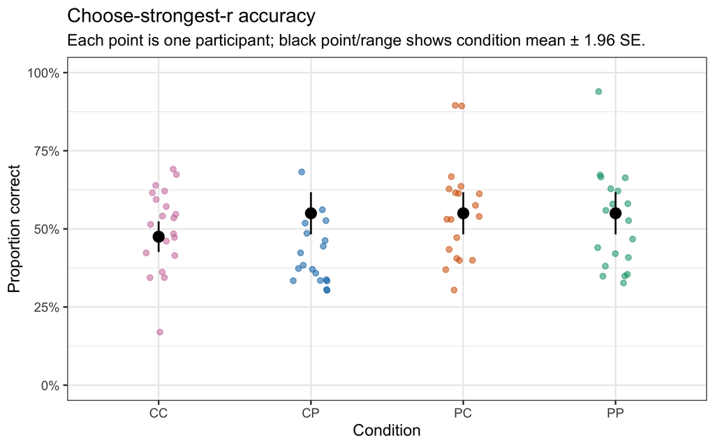

#### Condition estimates

| group | lecture_type | practice_type | condition_mean | se | lower_ci | upper_ci |
| --- | --- | --- | --- | --- | --- | --- |
| CC | Control | Control | 0.476 | 0.033 | 0.411 | 0.541 |
| CP | Control | PlotWise | 0.550 | 0.032 | 0.486 | 0.615 |
| PC | PlotWise | Control | 0.550 | 0.032 | 0.485 | 0.614 |
| PP | PlotWise | PlotWise | 0.549 | 0.033 | 0.484 | 0.614 |

#### Model coefficients

| term | estimate | std_error | statistic | p_value |
| --- | --- | --- | --- | --- |
| (Intercept) | 0.459 | 0.046 | 9.932 | < .001 |
| lecture_typePlotWise | 0.073 | 0.046 | 1.596 | 0.115 |
| practice_typePlotWise | 0.074 | 0.046 | 1.615 | 0.110 |
| prior_total | 0.015 | 0.031 | 0.483 | 0.631 |
| lecture_typePlotWise:practice_typePlotWise | -0.075 | 0.065 | -1.154 | 0.252 |

**Interpretation: choose-strongest-r.**  
The choose-strongest-r items are useful as a quick recognition check, but there are only two items, so I would keep this section descriptive rather than making a strong condition-level claim. Accuracy is close to chance overall: the lowest mean is in **CC** ( 47.5% ) and the highest mean is tied across **CP/PC/PP** ( 55.0% ). In the prior-knowledge-adjusted model, neither the PlotWise lecture term (p = 0.115 ) nor the PlotWise practice term (p = 0.110 ) shows a clear effect, and the interaction is also not clear (p = 0.252 ). This suggests that the recognition-based items are probably too few to be diagnostic on their own.

# 3. Open-ended text responses

The four text-response questions are coded manually using a simple 0 / 0.5 / 1 rubric. This keeps the coding consistent with the prior-knowledge coding sheet.

## 3.1 Rubric

### Q1. Switching X and Y: correlation

**Prompt:** A researcher has a correlation of .5 and a slope of .25. If they switched X and Y, what would happen to the correlation?

- **1** = Clearly says the correlation stays the same / remains .5 / is unchanged when X and Y are switched.
- **0.5** = Indicates the relationship or strength is the same, but the answer is vague or does not clearly name correlation.
- **0** = Says the correlation changes, becomes reciprocal, changes sign, becomes slope, or gives an irrelevant/missing answer.

### Q2. Switching X and Y: slope

**Prompt:** What would happen to the slope?

- **1** = Clearly says the slope changes when X and Y are switched, or says it becomes reciprocal/inverse because slope depends on which variable is on which axis / the units of X and Y.
- **0.5** = Says slope would change, flip, or become different, but the explanation is vague and does not clearly describe the reciprocal/inverse relationship.
- **0** = Says slope stays the same, confuses slope with correlation, or gives an irrelevant/missing answer.

### Q3. Ways slope and correlation are the same

**Prompt:** Please list as many ways slope and correlation are the same as you can think of.

- **1** = Mentions at least one meaningful similarity, such as both describe the direction of a linear relationship, both can be positive/negative/zero, or both summarize association/trend between two variables.
- **0.5** = Gives a vague but relevant similarity, such as both relate to a line/graph/relationship, without explaining direction or association clearly.
- **0** = Says they are unrelated, gives only incorrect statements, or gives an irrelevant/missing answer.

### Q4. Ways slope and correlation are different

**Prompt:** Please list as many ways slope and correlation are different as you can think of.

- **1** = Mentions at least one meaningful difference, such as correlation is standardized / bounded from -1 to 1 / unitless / about strength or tightness, while slope has units / depends on scale / describes rate of change or steepness.
- **0.5** = Gives a vague but relevant difference, such as correlation is about relationship and slope is about steepness, without much detail.
- **0** = Says they are the same, gives only incorrect statements, or gives an irrelevant/missing answer.

## 3.2 Create or load text coding sheet

**Loaded coded text file:** conceptual_text_coding_sheet_coded.csv

| responseId | question_label | score | n_responses |
| --- | --- | --- | --- |
| q-different | How slope and correlation are different | 0.0 | 25 |
| q-different | How slope and correlation are different | 0.5 | 20 |
| q-different | How slope and correlation are different | 1.0 | 35 |
| q-same | How slope and correlation are the same | 0.0 | 23 |
| q-same | How slope and correlation are the same | 0.5 | 22 |
| q-same | How slope and correlation are the same | 1.0 | 35 |
| switch-question-response-a | Switch X/Y: correlation | 0.0 | 26 |
| switch-question-response-a | Switch X/Y: correlation | 0.5 | 3 |
| switch-question-response-a | Switch X/Y: correlation | 1.0 | 51 |
| switch-question-response-b | Switch X/Y: slope | 0.0 | 30 |
| switch-question-response-b | Switch X/Y: slope | 0.5 | 11 |
| switch-question-response-b | Switch X/Y: slope | 1.0 | 39 |

## 3.3 Primary conceptual outcome: open-ended text-response score

| group | n_participants | mean_conceptual_question_score | sd_conceptual_question_score | mean_text_score |
| --- | --- | --- | --- | --- |
| CC | 20 | 1.725 | 1.175 | 0.431 |
| CP | 20 | 2.225 | 1.552 | 0.556 |
| PC | 20 | 2.675 | 1.217 | 0.669 |
| PP | 20 | 2.775 | 1.262 | 0.694 |

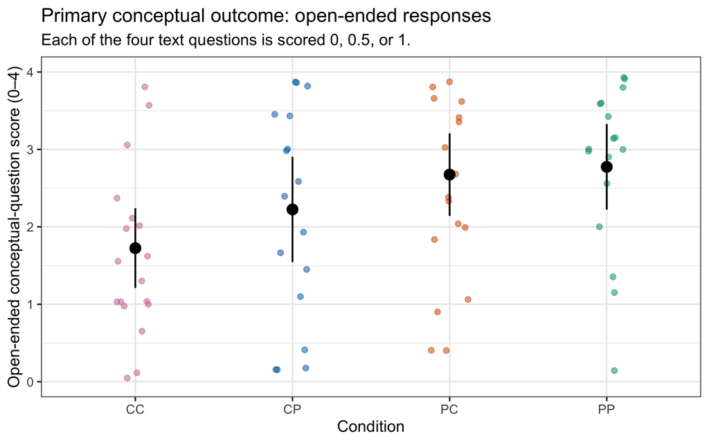

#### Condition estimates

| group | lecture_type | practice_type | condition_mean | se | lower_ci | upper_ci |
| --- | --- | --- | --- | --- | --- | --- |
| CC | Control | Control | 1.822 | 0.251 | 1.322 | 2.323 |
| CP | Control | PlotWise | 2.257 | 0.250 | 1.759 | 2.756 |
| PC | PlotWise | Control | 2.642 | 0.250 | 2.144 | 3.141 |
| PP | PlotWise | PlotWise | 2.677 | 0.251 | 2.177 | 3.178 |

#### Model coefficients

| term | estimate | std_error | statistic | p_value |
| --- | --- | --- | --- | --- |
| (Intercept) | 0.360 | 0.356 | 1.010 | 0.316 |
| lecture_typePlotWise | 0.820 | 0.355 | 2.311 | 0.024 |
| practice_typePlotWise | 0.435 | 0.354 | 1.228 | 0.223 |
| prior_total | 1.300 | 0.241 | 5.384 | < .001 |
| lecture_typePlotWise:practice_typePlotWise | -0.400 | 0.501 | -0.799 | 0.427 |

# 4. Working summary

The conceptual-question results suggest two different patterns. The choose-strongest-r items were close to chance and did not show clear condition differences, so they are best treated as a short recognition check rather than a main learning outcome.

The open-ended responses are more informative. Participants in the PlotWise lecture conditions, especially PC and PP, gave stronger explanations of slope and correlation than participants in the control-lecture conditions. This pattern remained after controlling for prior knowledge. Prior knowledge was also strongly related to open-response performance, which makes sense because both measure students’ baseline understanding of slope and correlation.

Overall, the clearest conceptual finding is that seeing PlotWise modeled in the lecture may have helped participants verbalize the relationship between slope and correlation. Practice type was weaker, and the interaction was not clear.